# Lab 9 内生解释变量

胡华平

2019-05-10

# 1 实验目的及要求

目的：掌握工具变量的选择；理解工具变量模型的计量分析和检验。

要求：熟悉两阶段最小二乘方法；熟练内生解释变量的豪斯曼检验和工具变量的外生性检验。

# 2 实验原理

## 2.1 解释变量为什么会是内生的？——模型遗漏变量

假定工资水平的**“真实模型”**为：

$$\begin {align}
\log (wage_i)=\beta_{0}+\beta_{1} educ_i+\beta_{2} abil_i+u_i
\end {align}$$

然而，因为能力变量（ *a**b**i**l*<sub>*i*</sub>）无法观测得到，所以我们经常用智商水平变量（ *I**Q*<sub>*i*</sub>）来替换，并构建如下**“代理变量模型”**：

$$\begin {align}
\log (wage_i)=\beta_{0}+\beta_{1} educ_i+\beta_{2} IQ_i+u_i^{\ast}
\end {align}$$

进一步地，如果拿不到智力水平（ *I**Q*<sub>*i*</sub>）数据，我们很可能构建出如下**遗漏重要变量**的**“偏误模型”**：

$$\begin {align}
\log (wage_i)=\beta_{0}+\beta_{1} educ_i+v_i
\end {align}$$

- 此时，我们可以认为重要变量 *a**b**i**l*<sub>*i*</sub>被遗漏，从而进入到随机干扰项 *v*<sub>*i*</sub>中。
- 又因为，一般情况下我们认为教育水平（ *e**d**u**c*<sub>*i*</sub>）与能力（ *a**b**i**l*<sub>*i*</sub>）是相关的，从而可以认为 自变量 *e**d**u**c*<sub>*i*</sub>与随机干扰项 *v*<sub>*i*</sub>是相关的。而这是违背CLRM假设的（违背了哪一条？）。

## 2.2 出现内生解释变量会有什么问题？

对于总体回归模型：

$$\begin{align}
Y_i &= \beta_1 +\beta_2X_i + u_i && \text{(PRM)}
\end{align}$$

- 在CLRM假设下：**CLRM假设3**——X是固定的（给定的）或独立于误差项。也即自变量X**不是**随机变量。此时，我们可以使用OLS方法，并得到**BLUE**。

$$\begin{align}
Cov(X_i, u_i)= 0\\
E(X_i u_i)= 0
\end{align}$$

- 如果违背上述假设，也即自变量X与随机干扰项相关。此时使用OLS估计将不再能得到**BLUE**，而应该采用**工具变量法**（IV）进行估计。

## 2.3 什么是工具变量？

**代理变量**（proxy variable）：一般因为某些原因，某个变量 *X*<sub>*i*</sub>不能直接观测得到（数据不可得），那么常常会找一个能够观测到到的、并与 *X*<sub>*i*</sub>高度相关的变量 *D*<sub>*i*</sub>作为替代。

- 假定工资水平的**“真实模型”**为：

$$\begin {align}
\log (wage_i)=\beta_{0}+\beta_{1} educ_i+\beta_{2} abil_i+u_i
\end {align}$$

- 然而，因为能力变量（ *a**b**i**l*<sub>*i*</sub>）无法观测得到，所以我们经常用智商水平变量（ *I**Q*<sub>*i*</sub>）来替换，并构建如下**“代理变量模型”**：

$$\begin {align}
\log (wage_i)=\beta_{0}+\beta_{1} educ_i+\beta_{2} IQ_i+u_i^{\ast}
\end {align}$$

此时，智力水平 *I**Q*<sub>*i*</sub>就可以认为是变量 能力 *a**b**i**l*<sub>*i*</sub>的**代理变量**。

**代理变量**（proxy variable）：一般因为某些原因，某个变量 *X*<sub>*i*</sub>不能直接观测得到（数据不可得），那么常常会找一个能够观测到到的、并与 *X*<sub>*i*</sub>高度相关的变量 *D*<sub>*i*</sub>作为替代。

**工具变量**（instrument variable）：一般记为 *Z*<sub>*i*</sub>，是指一个具备如下**两个性质**的可观测的变量：

$$\begin{align}
Y_i &= \beta_1 +\beta_2X_i + u_i && \text{(PRM)}
\end{align}$$

$$\begin{align}
Cov(Z_i, u_i) & = 0 && \text{(instrumental exogeneity)}\\
Cov(Z_i, X_i) & \neq 0 && \text{(instrumental relevance)}
\end{align}$$

- 工具外生性（instrumental exogeneity）：工具变量对于总体回归模型是外生的。
- 工具相关性（instrumental relevance）：工具变量对于解释 *X*<sub>*i*</sub>的变异时有很重要的作用。

**思考**： 我们很容易就能检验出模型是不是具有工具外生性或工具相关性么？为什么？

从遗漏变量角度来看，工具变量 *Z*<sub>*i*</sub>对 *Y*<sub>*i*</sub>没有多余的影响，并且 *Z*<sub>*i*</sub>与遗漏变量也不相关。

$$\begin{align}
X_i &= \pi_1 +\pi_2Z_i + v_i \\
\pi_2 & = \frac{cov(X_i,Z_i)}{var(Z_i)}
\end{align}$$

## 2.4 多元回归模型下如何进行两阶段最小二乘法估计

对于多元回归模型，我们可以记为：

$$\begin {align}
\log (wage) & = \beta_{1}+\beta_{2} educ+\lambda_{1} exper+u_{i} \\
Y_{1i} & =\beta_{1}+\beta_{2} Y_{2i}+\lambda_{1} Z_{1i}+u_{i} \\
E(u_i)&=0; \quad cov(Y_{2i}, u_i) \neq 0 ;\\
cov(Z_{1i},u_i)&=0;\quad cov(Y_{2i},Z_{1i})=0
\end {align}$$

- **内生变量**（endogenous variable）：用符号 *Y*<sub>*i*</sub>表达。例如，因变量（工资水平） *Y*<sub>1*i*</sub>显然是内生变量；而其中的一个自变量（教育年数） *Y*<sub>2*i*</sub>我们在这里认为也是内生的——也即允许它跟随机干扰项 *u*<sub>*i*</sub>**相关**。
- **外生变量**（exogenous variable）：用符号 *Z*<sub>*i*</sub>表达。例如另一个自变量（工作经历） *Z*<sub>1*i*</sub>则认为它是外生的——也即它跟随机干扰项 *u*<sub>*i*</sub>**不相关**。

约简方程可以写成：

$$\begin {align}
\log (wage) & = \beta_{1}+\beta_{2} educ+\lambda_{1} exper+u_{i} \\
Y_{1i} & =\beta_{1}+\beta_{2} Y_{2i}+\lambda_{1} Z_{1i}+u_{i} \\
\end {align}$$

如果我们给内生变量 *Y*<sub>2*i*</sub>找到一个理想的工具变量 *Z*<sub>2*i*</sub>，则可以构建如下的**约简方程**：

$$\begin {align}
Y_{2i} & =\pi_{0}+\pi_{1} Z_{1i}+\pi_{2} Z_{2i}+v_{i} \\
E(v_i)&=0; \quad cov(Y_{2i},Z_{1i})=0;\\
cov(Z_{1i},v_i) &=0; \quad cov(Z_{2i}, v_i) = 0
\end {align}$$

- **约简方程**（reductive equation）：是指一个**内生变量**对全部**外生变量**的回归方程。
- 因为 *Z*<sub>1*i*</sub>; *Z*<sub>2*i*</sub>为外生变量都为**外生变量**，所以满足CLRM假设，上述**偏相关分析模型**可以直接使用OLS方法而得到**BLUE**。**偏相关分析模型**可以用于检验 *Y*<sub>2*i*</sub>与 *Z*<sub>2*i*</sub>是否相关，也即检验： *H*<sub>0</sub> : *π*<sub>2</sub> = 0; *H*<sub>1</sub> : *π*<sub>2</sub> ≠ 0。具体可以采用通常的**t检验**方法。

**两阶段最小二乘法**（2SLS）的具体实施为：

$$\begin {align}
\log (wage) & = \beta_{1}+\beta_{2} educ+\lambda_{1} exper+u_{i} \\
Y_{1i} & =\beta_{1}+\beta_{2} Y_{2i}+\lambda_{1} Z_{1i}+u_{i} \\
\end {align}$$

第一阶段OLS回归：对约简方程进行回归。

$$\begin {align}
Y_{2i} & =\pi_{0}+\pi_{1} Z_{1i}+\pi_{2} Z_{2i}+v_{i}
&& \leftarrow \left[ \pi_2 \neq 0 \right]\\
\hat{Y}_{2i} & =\pi_{0}+\pi_{1} Z_{1i}+\pi_{2} Z_{2i}
\end {align}$$

第二阶段OLS回归：基于估计值进行回归。

$$\begin {align}
Y_{1i} & =\alpha_{0}+\alpha_{1} Z_{1i}+\beta_{2} \hat{Y}_{2i}+\epsilon_{i}
\end {align}$$

## 2.5 如何检验解释变量是内生性的？

**工具变量**（instrument variable）具备如下**两个性质**：

$$\begin{align}
Cov(Z_i, u_i) & = 0 && \text{(instrumental exogeneity)}\\
Cov(Z_i, X_i) & \neq 0 && \text{(instrumental relevance)}
\end{align}$$

我们先来检验**第二个**条件：一个变量 *X*<sub>*i*</sub>是否真的是**内生性**的？

给定如下的**“偏误回归模型”**：

$$\begin {align}
Y_{1i} & =\beta_{1}+\beta_{2} Y_{2i}+\lambda_{1} Z_{1i} +\lambda_{2} Z_{2i}+u_{i} && \text{(stucture eq.)}
\end {align}$$

- 仅有1个疑似**内生变量** *Y*<sub>2*i*</sub>；2个**外生变量** *Z*<sub>1*i*</sub>; *Z*<sub>2*i*</sub>。
- 假定已经找到了变量 *Y*<sub>2*i*</sub>的两个理想**工具变量** *Z*<sub>3*i*</sub>; *Z*<sub>4*i*</sub>。

我们可以利用**两阶段最小二乘法**（2SLS）方法进行估计：

$$\begin{align}
Y_{2i} &= \pi_{0} + \pi_{1}Z_{1i} + \pi_{2}Z_{2i} + \pi_{3}Z_{3i} + \pi_{4}Z_{4i} +v_i && \text{( 1st eq. / reduce eq. )} \\
Y_{1i} & =\alpha_{1}+\alpha_{2} \hat{Y}_{2i}+\gamma_{1} Z_{1i} +\gamma_{2} Z_{2i} + \epsilon_i && \text{( 2st eq. )}
\end{align}$$

豪斯曼检验的操作过程如下：

**步骤1**：明确**外生变量**（ *Z*<sub>1*i*</sub>, *Z*<sub>2*i*</sub>）；**疑似内生变量**（ *Y*<sub>2*i*</sub>）及其**工具变量**（ *Z*<sub>3*i*</sub>; *Z*<sub>4*i*</sub>）：

$$\begin {align}
Y_{1i} & =\beta_{1}+\beta_{2} Y_{2i}+\lambda_{1} Z_{1i} +\lambda_{2} Z_{2i}+u_{i} && \text{(stucture eq.)} \\
Y_{2i} &= \pi_{0} + \pi_{1}Z_{1i} + \pi_{2}Z_{2i} + \pi_{3}Z_{3i} + \pi_{4}Z_{4i} +v_i && \text{( 1st eq. / reduce eq. )} \\
Y_{1i} & =\alpha_{1}+\alpha_{2} \hat{Y}_{2i}+\gamma_{1} Z_{1i} +\gamma_{2} Z_{2i} + \epsilon_i && \text{( 2st eq. )}
\end {align}$$

**步骤2**：采用**OLS方法**估计**约简方程**并得到残差 *v̂*<sub>*i*</sub>：

$$\begin{align}
\hat{v}_i = Y_{2i}- \hat{\pi}_{0} - \hat{\pi}_{1}Z_{1i} - \hat{\pi}_{2}Z_{2i} + \hat{\pi}_{3}Z_{3i} - \hat{\pi}_{4}Z_{4i} = Y_{2i}- \hat{Y}_{2i}
\end{align}$$

**步骤3**：采用**OLS方法**估计**豪斯曼检验方程**：

$$\begin{align}
Y_{1i} & =\beta_{1}+\beta_{2} Y_{2i}+\lambda_{1} Z_{1i} +\lambda_{2} Z_{2i}+\delta \hat{v}_{i} + \varepsilon_i
\end{align}$$

**步骤4**：做出判断并得到**内生性检验**的结论：

给出检验假设： *H*<sub>0</sub> : *δ* = 0; *H*<sub>1</sub> : *δ* ≠ 0。在给定置信水平 *α*，对**豪斯曼检验方程**中的 *δ*进行t检验（需要进行**异方差矫正**）：

- 如果t检验**显著**，则拒绝原假设 *H*<sub>0</sub>，表明 *Y*<sub>2*i*</sub>是**内生的**。
- 如果t检验结果**不显著**，则不能拒绝原假设 *H*<sub>0</sub>，表明 *Y*<sub>2*i*</sub>是**外生的**。

## 2.6 如何检验工具变量是外生的？

**工具变量**（instrument variable）具备如下**两个性质**：

$$\begin{align}
Cov(Z_i, u_i) & = 0 && \text{(instrumental exogeneity)}\\
Cov(Z_i, X_i) & \neq 0 && \text{(instrumental relevance)}
\end{align}$$

我们现在来检验**第一个**条件：工具变量 *Z*<sub>*i*</sub>是否真的是**外生性**的？

- 因为 *u*<sub>*i*</sub>不能直接观测得到，所以第一个条件的检验往往不是很直接。
- 如果只有一个**工具变量**，第一个条件往往不能检验。（为什么？）

考虑如下**分析情形**：有明确的**外生变量**（ *Z*<sub>1*i*</sub>, *Z*<sub>2*i*</sub>）；有**疑似内生变量**（ *Y*<sub>2*i*</sub>）及其2个**工具变量**（ *Z*<sub>3*i*</sub>; *Z*<sub>4*i*</sub>）。考虑如下的一个**偏误模型**（结构模型）：

$$\begin {align}
Y_{1i} & =\beta_{1}+\beta_{2} Y_{2i}+\lambda_{1} Z_{1i} +\lambda_{2} Z_{2i}+u_{i} && \text{(stucture eq.)}
\end {align}$$

外生性检验的具体操作过程如下：

**步骤1**：用两阶段法估计**结构方程**（使用2个工具变量），获得2SLS的残差 *û*<sub>*i*</sub>：

$$\begin {align}
Y_{1i} & =\beta_{1}+\beta_{2} Y_{2i}+\lambda_{1} Z_{1i} +\lambda_{2} Z_{2i}+u_{i} && \text{(stucture eq.)} \\
Y_{2i} &= \pi_{0} + \pi_{1}Z_{1i} + \pi_{2}Z_{2i} + \pi_{3}Z_{3i} + \pi_{4}Z_{4i} +v_i && \text{( 1st eq. / reduce eq. )} \\
Y_{1i} & =\alpha_{1}+\alpha_{2} \hat{Y}_{2i}+\gamma_{1} Z_{1i} +\gamma_{2} Z_{2i} + \epsilon_i && \text{( 2st eq. )}
\end {align}$$

**步骤2**：构建外生性检验模型。将残差 *û*<sub>*i*</sub>对所有外生变量进行回归，并获得判定系数 *R*<sup>2</sup>。

$$\begin{align}
\hat{u}_{i} & =\lambda_{0}+\lambda_{1} Z_{1i} +\lambda_{2} Z_{2i}+\lambda_{3} Z_{3i} +\lambda_{4} Z_{4i} + \varepsilon_i
\end{align}$$

**步骤3**：构建**卡方统计量**，根据原假设（ *H*<sub>0</sub>:全部工具变量都是**外生的**）/备择假设（ *H*<sub>1</sub>:部分工具变量不是**外生的**），做出判断并得到假设检验结论。

$$\begin{align}
{\chi^2}^\ast & = nR^2 \simeq \chi^2(q) && \leftarrow [q =(n_{iv} -n_{env})]
\end{align}$$

- 卡方分布的自由度为 *q* = (*n*<sub>*i**v*</sub> − *n*<sub>*e**n**v*</sub>)，其中 *n*<sub>*i**v*</sub>指**工具变量**的个数（也即 (*m**o**t**h**e**d**u*<sub>*i*</sub>, *f**a**t**h**e**d**u**c*<sub>*i*</sub>)）， *n*<sub>*e**n**v*</sub>指**内生变量**的个数（也即 *e**d**u*<sub>*i*</sub>）——（不包括结构模型中的因变量 *l**o**g*(*w**a**g**e*<sub>*i*</sub>)）。
- 如果卡方统计量值**大于**查表值，也即 *χ*<sup>2</sup>* > *χ*<sub>1 − *α*</sub><sup>2</sup>(*q*)，则拒绝原假设 *H*<sub>0</sub>，接收备择假设 *H*<sub>1</sub>，表明**至少**部分工具变量**不是外生的**。
- 如果卡方统计量值**小于**查表值，也即 *χ*<sup>2</sup>* < *χ*<sub>1 − *α*</sub><sup>2</sup>(*q*)，则接受原假设 *H*<sub>0</sub>，表明**全部**工具变量**是外生的**。

# 3 实验内容：已婚女性的教育回报案例

研究者关注428名已婚女性**时均工资** *w**a**g**e*与其**受教育年数** *e**d**u**c*之间的关系，并考虑如下变量：

| vars | mark |
| --- | --- |
| wage | ['时均工资'] |
| educ | ['受教育年数'] |
| exper | ['就业次数'] |
| fatheduc | ['父亲的受教育年数'] |
| motheduc | ['母亲的受教育年数'] |
| inlf | ['是否是劳动力'] |
| hours | ['工作时长'] |
| kidslt6 | ['六岁以下孩子数'] |
| kidsge6 | ['6-18岁孩子数'] |
| age | ['年龄'] |

[output cut: 12 more lines]

原始数据如下：

|  | wage | educ | exper | fatheduc | motheduc |
| --- | --- | --- | --- | --- | --- |
| 1 | 3.35400009155273 | 12 | 14 | 7 | 12 |
| 2 | 1.3889000415802 | 12 | 5 | 7 | 7 |
| 3 | 4.54549980163574 | 12 | 15 | 7 | 12 |
| 4 | 1.09650003910065 | 12 | 6 | 7 | 7 |
| 5 | 4.59180021286011 | 14 | 7 | 14 | 12 |
| 6 | 4.74209976196289 | 12 | 33 | 7 | 14 |
| 7 | 8.33329963684082 | 16 | 11 | 7 | 14 |
| 8 | 7.84310007095337 | 12 | 35 | 3 | 3 |
| 9 | 2.12619996070862 | 12 | 24 | 7 | 7 |
| 10 | 4.6875 | 12 | 21 | 7 | 7 |

[output cut: 418 more lines]

# 4 实验步骤

## 4.1 偏误OLS回归：EViews报告

下面给出EViews软件分析报告：

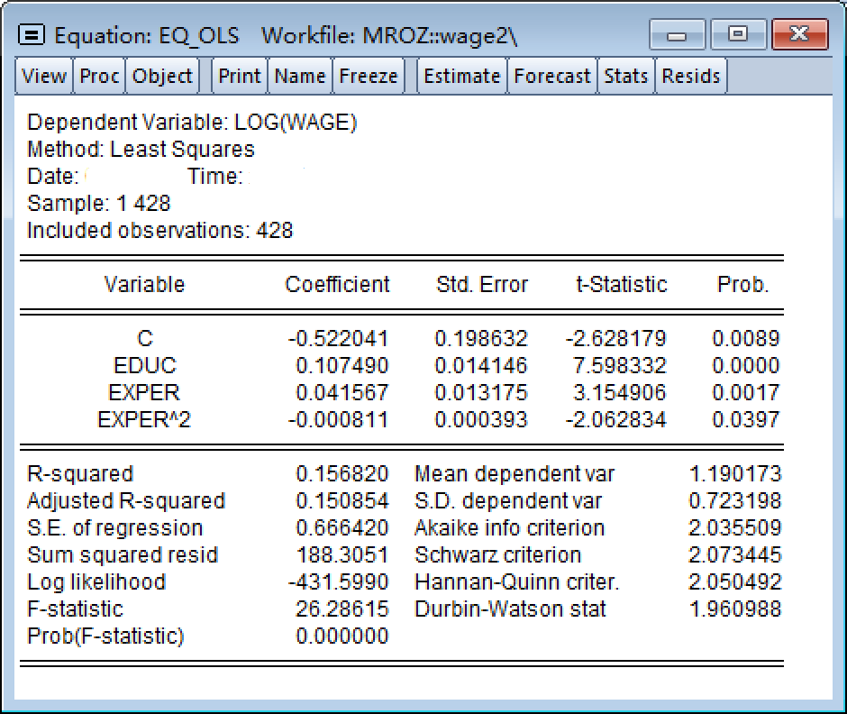

偏误OLS回归的精炼报告如下：

如果认为工作经历 *e**x**p**e**r*是**外生变量**变量；且认为已婚女性的受教育年数 *e**d**u**c*为**内生变量**。直接构建如下的**“偏误模型”**，并坚持采用OLS方法，估计结果为：

$$\begin{equation} \begin{alignedat}{999} &log(wage)=&& + \beta_{1} && + \beta_{2} educ&& + \beta_{3} exper&& + \beta_{4} I(exper^2)&&+u_i\\ \end{alignedat} \end{equation}$$

$$\begin{equation} \begin{alignedat}{999} &\widehat{log(wage)}=&&-0.52&&+0.11educ&&+0.04exper\\ &\text{(t)}&&(-2.6282)&&(7.5983)&&(3.1549)\\&\text{(se)}&&(0.1986)&&(0.0141)&&(0.0132)\\&\text{(cont.)}&&-0.00I(exper^2)\\&\text{(t)}&&(-2.0628)\\&\text{(se)}&&(0.0004)\\&\text{(fitness)}&& R^2=0.1568;&& \bar{R^2}=0.1509\\& && F^{\ast}=26.29;&& p=0.0000\\ \end{alignedat} \end{equation}$$

## 4.2 两阶段回归法（2SLS）

假设**父亲受教育年数** *f**a**t**h**e**d**u**c*和**母亲受教育年数** *m**o**t**h**e**d**u**c*都是已婚女性**受教育年数** *e**d**u**c*的理想**工具变量**。

采用工具变量法的对如下**约简方程**：

$$\begin{align}
educ = &\pi_{1} + \pi_{2} exper + \pi_{3} exper^2 \\
&+ \pi_{4} fatheduc + \pi_{5} motheduc+v_i
\end{align}$$

对以上**约简方程**进行第一阶段OLS回归，估计结果为：

$$\begin{equation} \begin{alignedat}{999} &\widehat{educ}=&&+9.10&&+0.05exper&&-0.00I(exper^2)\\ &\text{(t)}&&(21.3396)&&(1.1236)&&(-0.8386)\\&\text{(se)}&&(0.4266)&&(0.0403)&&(0.0012)\\&\text{(cont.)}&&+0.19fatheduc&&+0.16motheduc\\&\text{(t)}&&(5.6152)&&(4.3906)\\&\text{(se)}&&(0.0338)&&(0.0359)\\&\text{(fitness)}&& R^2=0.2115;&& \bar{R^2}=0.2040\\& && F^{\ast}=28.36;&& p=0.0000\\ \end{alignedat} \end{equation}$$

利用前述第一阶段回归得到的 $\widehat{educ}$以及原来的**外生变量** *e**x**p**e**r*，我们可以构建如下的第二阶段回归模型：

$$\begin {align}
log(wage) & =\alpha_{1}+\alpha_{2} exper_{i}+\alpha_{3} exper_{i}^2 +\beta_{1} \widehat{educ}_{i}+\epsilon_{i}
\end {align}$$

两阶段最小二乘法（2SLS,不调整方差），EViews软件的具体设置为：

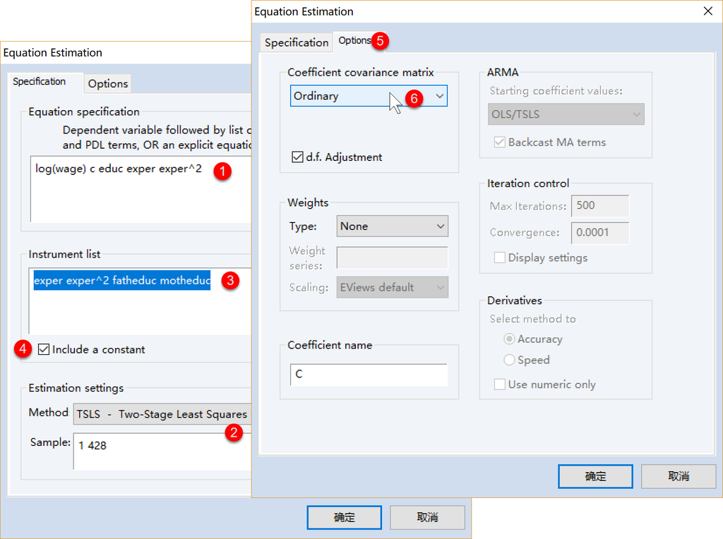

两阶段最小二乘法（2SLS,不调整方差），EViews软件的最终分析结果：

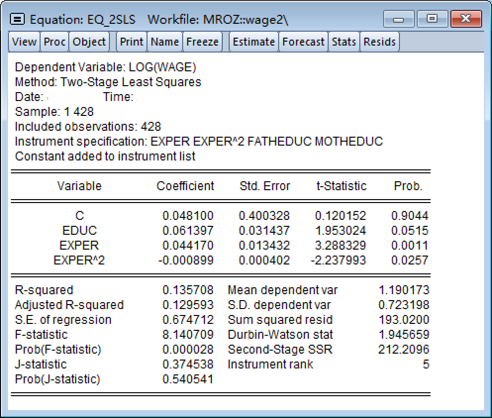

采用OLS方法对以上模型进行估计，得到精简报告结果如下：

$$\begin{equation} \begin{alignedat}{999} &\widehat{log(wage)}=&&+0.05&&+0.06educ.hat&&+0.04exper\\ &\text{(t)}&&(0.1146)&&(1.8626)&&(3.1361)\\&\text{(se)}&&(0.4198)&&(0.0330)&&(0.0141)\\&\text{(cont.)}&&-0.00I(exper^2)\\&\text{(t)}&&(-2.1344)\\&\text{(se)}&&(0.0004)\\&\text{(fitness)}&& R^2=0.0498;&& \bar{R^2}=0.0431\\& && F^{\ast}=7.40;&& p=0.0001\\ \end{alignedat} \end{equation}$$

## 4.3 解释变量的内生性检验：豪斯曼检验（Hausman Test）

明确变量和模型。

如果认为工作经历 *e**x**p**e**r*是**明确外生变量**。认为已婚女性的受教育年数 *e**d**u**c*为**疑似内生变量**，如果找到它的2个**工具变量**分别为母亲受教育年数 *m**o**t**h**e**d**u**c*和父亲受教育年数 *f**a**t**h**e**d**u**c*：

$$\begin {align}
log(wage_i) & =\beta_1+\beta_2 educ_i+\lambda_1 exper_i +\lambda_{2} exper^2_i+u_{i} && \text{(stucture eq.)} \\
educ_i &= \pi_{0} + \pi_{1}exper_i + \pi_{2}exper^2_i && \\
&+ \pi_{3}motheduc_{i} + \pi_{4}fatheduc_{i} +v_i && \text{( 1st eq. / reduce eq. )} \\
log(wage_i) & =\alpha_{1}+\alpha_{2} \widehat{educ}_i+\gamma_{1} exper_i +\gamma_{2} exper^2_i+ \epsilon_i && \text{( 2st eq. )}
\end {align}$$

采用**OLS方法**估计**约简方程**并得到残差 *v̂*<sub>*i*</sub>：

$$\begin{align}
\hat{v}_i = Y_{2i}- \hat{\pi}_{0} - \hat{\pi}_{1}Z_{1i} - \hat{\pi}_{2}Z_{2i} + \hat{\pi}_{3}Z_{3i} - \hat{\pi}_{4}Z_{4i} = Y_{2i}- \hat{Y}_{2i}
\end{align}$$

对以上**约简方程**进行OLS回归，估计结果为：

$$\begin{equation} \begin{alignedat}{999} &\widehat{educ}=&&+9.10&&+0.05exper&&-0.00I(exper^2)\\ &\text{(t)}&&(21.3396)&&(1.1236)&&(-0.8386)\\&\text{(se)}&&(0.4266)&&(0.0403)&&(0.0012)\\&\text{(cont.)}&&+0.19fatheduc&&+0.16motheduc\\&\text{(t)}&&(5.6152)&&(4.3906)\\&\text{(se)}&&(0.0338)&&(0.0359)\\&\text{(fitness)}&& R^2=0.2115;&& \bar{R^2}=0.2040\\& && F^{\ast}=28.36;&& p=0.0000\\ \end{alignedat} \end{equation}$$

估计简约方程得到残差数据如下：

|  | wage | educ | fatheduc | motheduc | exper | educ.hat | vi.hat |
| --- | --- | --- | --- | --- | --- | --- | --- |
| 1 | 3.35400009155273 | 12 | 7 | 12 | 14 | 12.756017473225 | -0.756017473224986 |
| 2 | 1.3889000415802 | 12 | 7 | 7 | 5 | 11.7335580528393 | 0.266441947160748 |
| 3 | 4.54549980163574 | 12 | 7 | 12 | 15 | 12.7719792588351 | -0.771979258835125 |
| 4 | 1.09650003910065 | 12 | 7 | 7 | 6 | 11.7676834756791 | 0.232316524320935 |
| 5 | 4.59180021286011 | 14 | 14 | 12 | 7 | 13.9146147514322 | 0.0853852485677888 |
| 6 | 4.74209976196289 | 12 | 7 | 14 | 33 | 13.0293763579735 | -1.02937635797346 |
| 7 | 8.33329963684082 | 16 | 7 | 14 | 11 | 13.0112170904032 | 2.98878290959675 |
| 8 | 7.84310007095337 | 12 | 3 | 3 | 35 | 10.4908298336813 | 1.50917016631872 |
| 9 | 2.12619996070862 | 12 | 7 | 7 | 24 | 12.0368319794436 | -0.0368319794435641 |
| 10 | 4.6875 | 12 | 7 | 7 | 21 | 12.0373829885555 | -0.0373829885555029 |

[output cut: 418 more lines]

为了检验 *e**d**u**c*<sub>*i*</sub>是否为**内生变量**，构建如下**豪斯曼检验模型**：

$$\begin{align}
log(wage_i) & =\beta_{1}+\beta_{2} educ_i+\lambda_{1} exper_i +\lambda_{2} exper^2_i+\delta \hat{v}_{i} + \varepsilon_i
\end{align}$$

对以上**豪斯曼检验方程**进行OLS回归，估计结果为：

$$\begin{equation} \begin{alignedat}{999} &\widehat{log(wage)}=&&+0.05&&+0.06educ&&+0.04exper\\ &\text{(t)}&&(0.1219)&&(1.9815)&&(3.3363)\\&\text{(se)}&&(0.3946)&&(0.0310)&&(0.0132)\\&\text{(cont.)}&&-0.00I(exper^2)&&+0.06vi.hat\\&\text{(t)}&&(-2.2706)&&(1.6711)\\&\text{(se)}&&(0.0004)&&(0.0348)\\&\text{(fitness)}&& R^2=0.1624;&& \bar{R^2}=0.1544\\& && F^{\ast}=20.50;&& p=0.0000\\ \end{alignedat} \end{equation}$$

可以看到 *v̂*<sub>*i*</sub>（也即`vi.hat`）前的系数 *δ*对应的t样本统计量值为`1.6711`。

- 若给定置信水平 *α* = 0.05，查t表可知 *t*<sub>1 − *α*/2</sub>(*n* − *k*) = *t*<sub>0.975</sub>(428 − 5)= 1.9656。因此 *t** < *t*<sub>1 − *α*/2</sub>(*n* − *k*)，不能拒绝原假设 *H*<sub>0</sub>，认为模型中的 *e**d**u**c*是**外生的**。
- 若给定置信水平 *α* = 0.1，查t表可知 *t*<sub>1 − *α*/2</sub>(*n* − *k*) = *t*<sub>0.95</sub>(428 − 5)= 1.6485。因此 *t** > *t*<sub>1 − *α*/2</sub>(*n* − *k*)，则拒绝原假设 *H*<sub>0</sub>，接受备择假设 *H*<sub>1</sub>，认为模型中的 *e**d**u**c*是**内生的**。

豪斯曼检验EViews操作展示如下：

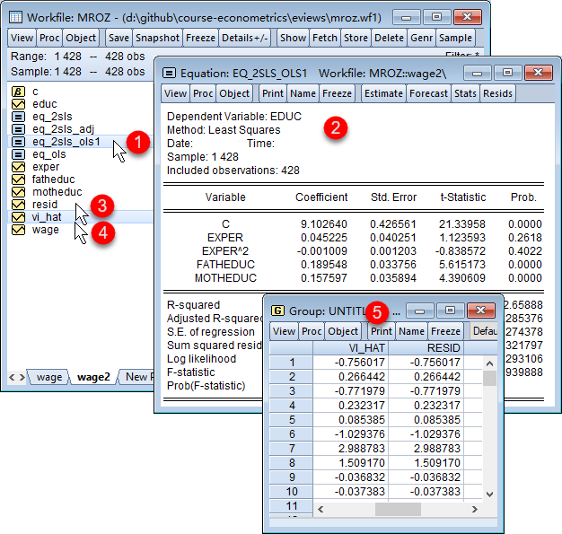

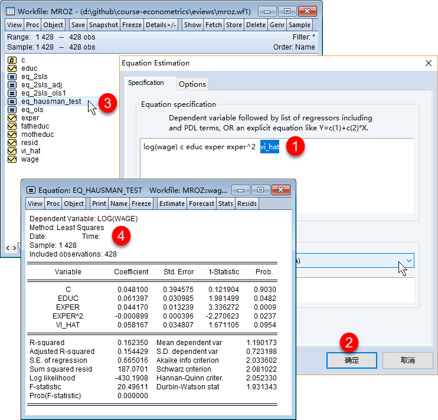

豪斯曼检验的EViews分析最终结果如下：

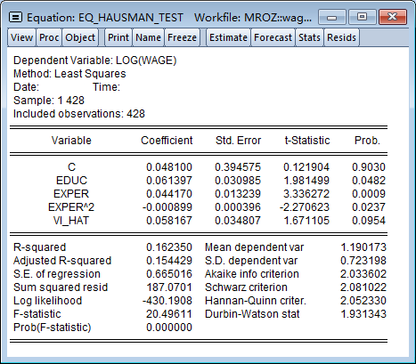

## 4.4 工具变量的外生性检验

首先需要明确变量和模型：

如果认为工作经历 *e**x**p**e**r*是**明确外生变量**。认为已婚女性的受教育年数 *e**d**u**c*为**疑似内生变量**，如果找到它的2个**工具变量**分别为母亲受教育年数 *m**o**t**h**e**d**u**c*和父亲受教育年数 *f**a**t**h**e**d**u**c*：

$$\begin {align}
log(wage_i) & =\beta_1+\beta_2 educ_i+\lambda_1 exper_i +\lambda_{2} exper^2_i+u_{i} && \text{(stucture eq.)} \\
educ_i &= \pi_{0} + \pi_{1}exper_i + \pi_{2}exper^2_i && \\
&+ \pi_{3}motheduc_{i} + \pi_{4}fatheduc_{i} +v_i && \text{( 1st eq. / reduce eq. )} \\
log(wage_i) & =\alpha_{1}+\alpha_{2} \widehat{educ}_i+\gamma_{1} exper_i +\gamma_{2} exper^2_i && \text{( 2st eq. )}
\end {align}$$

采用**2SLS方法**估计前述**结构方程**并得到残差 *û*<sub>*i*</sub>，`R软件`估计结果为：

```
Call:
ivreg(formula = log(wage) ~ educ + exper + I(exper^2) | exper +
    I(exper^2) + fatheduc + motheduc, data = mroz)

Residuals:
    Min      1Q  Median      3Q     Max
-3.0986 -0.3196  0.0551  0.3689  2.3493

Coefficients:
             Estimate Std. Error t value Pr(>|t|)
(Intercept)  0.048100   0.400328    0.12   0.9044
educ         0.061397   0.031437    1.95   0.0515 .
exper        0.044170   0.013432    3.29   0.0011 **
I(exper^2)  -0.000899   0.000402   -2.24   0.0257 *
---
Signif. codes:
0 '***' 0.001 '**' 0.01 '*' 0.05 '.' 0.1 ' ' 1

Residual standard error: 0.675 on 424 degrees of freedom
Multiple R-Squared: 0.136,  Adjusted R-squared: 0.13
Wald test: 8.14 on 3 and 424 DF,  p-value: 0.0000279
```

可以获得2SLS的残差数据：

|  | wage | educ | fatheduc | motheduc | exper | educ.hat | vi.hat | ui.hat |
| --- | --- | --- | --- | --- | --- | --- | --- | --- |
| 1 | 3.35400009155273 | 12 | 7 | 12 | 14 | 12.756017473225 | -0.756017473224986 | -0.0168936207790957 |
| 2 | 1.3889000415802 | 12 | 7 | 7 | 5 | 11.7335580528393 | 0.266441947160748 | -0.654725475713332 |
| 3 | 4.54549980163574 | 12 | 7 | 12 | 15 | 12.7719792588351 | -0.771979258835125 | 0.268990102628786 |
| 4 | 1.09650003910065 | 12 | 7 | 7 | 6 | 11.7676834756791 | 0.232316524320935 | -0.925395975965052 |
| 5 | 4.59180021286011 | 14 | 14 | 12 | 7 | 13.9146147514322 | 0.0853852485677888 | 0.351475803505815 |
| 6 | 4.74209976196289 | 12 | 7 | 14 | 33 | 13.0293763579735 | -1.02937635797346 | 0.292975100461763 |
| 7 | 8.33329963684082 | 16 | 7 | 14 | 11 | 13.0112170904032 | 2.98878290959675 | 0.712714125556681 |
| 8 | 7.84310007095337 | 12 | 3 | 3 | 35 | 10.4908298336813 | 1.50917016631872 | 0.830048328829994 |
| 9 | 2.12619996070862 | 12 | 7 | 7 | 24 | 12.0368319794436 | -0.0368319794435641 | -0.572806464055426 |
| 10 | 4.6875 | 12 | 7 | 7 | 21 | 12.0373829885555 | -0.0373829885555029 | 0.228906879819095 |

[output cut: 418 more lines]

下面可以构建外生性检验模型：

将残差 *û*<sub>*i*</sub>对所有外生变量进行回归，并获得判定系数 *R*<sup>2</sup>。

$$\begin{align}
\hat{u}_{i} & =\lambda_{0}+\lambda_{1} exper_i +\lambda_{2} exper^2_i+\lambda_{3} montheduc_i +\lambda_{4} fatheduc_i + \varepsilon_i
\end{align}$$

$$\begin{equation} \begin{alignedat}{999} &\widehat{ui.hat}=&&+0.01&&-0.00exper&&+0.00I(exper^2)\\ &\text{(t)}&&(0.0776)&&(-0.0014)&&(0.0018)\\&\text{(se)}&&(0.1413)&&(0.0133)&&(0.0004)\\&\text{(cont.)}&&-0.01motheduc&&+0.01fatheduc\\&\text{(t)}&&(-0.5558)&&(0.5173)\\&\text{(se)}&&(0.0119)&&(0.0112)\\&\text{(fitness)}&& R^2=0.0009;&& \bar{R^2}=-0.0086\\& && F^{\ast}=0.09;&& p=0.9845\\ \end{alignedat} \end{equation}$$

进一步地，可以外生性检验验结论：

- 原假设（ *H*<sub>0</sub>:全部工具变量都是**外生的**）/备择假设（ *H*<sub>1</sub>:部分工具变量不是**外生的**）.
- 构建并计算**卡方统计量**。容易发现，判定系数 *R*<sup>2</sup>= 0.0009。可以计算得到样本卡方统计量为 *χ*<sup>2</sup>* = *n**R*<sup>2</sup>= 0.3781。
- 查卡方分布。容易计算出卡方分布的自由度为： *q* = (*n*<sub>*i**v*</sub> − *n*<sub>*e**n**v*</sub>)= 1，其中 *n*<sub>*i**v*</sub>= 2（**工具变量**的个数，也即 (*m**o**t**h**e**d**u*<sub>*i*</sub>, *f**a**t**h**e**d**u**c*<sub>*i*</sub>)。 *n*<sub>*e**n**v*</sub>= 1（**内生变量**的个数，也即 *e**d**u*<sub>*i*</sub>）。若给定置信水平 *α* = 0.05，查卡方分布表可知 *χ*<sub>1 − *α*</sub><sup>2</sup>(*q*) = *χ*<sub>0.95</sub><sup>2</sup>(1)= 3.8415。
- 给出假设检验结论。因为 *χ*<sup>2</sup>* < *χ*<sub>1 − *α*</sub><sup>2</sup>(*q*)，不能拒绝原假设 *H*<sub>0</sub>，认为模型中的工具变量 (*m**o**t**h**e**d**u**c*<sub>*i*</sub>, *f**a**t**h**e**d**u**c*<sub>*i*</sub>)都是**外生的**。

工具外生性检验EViews操作演示如下：

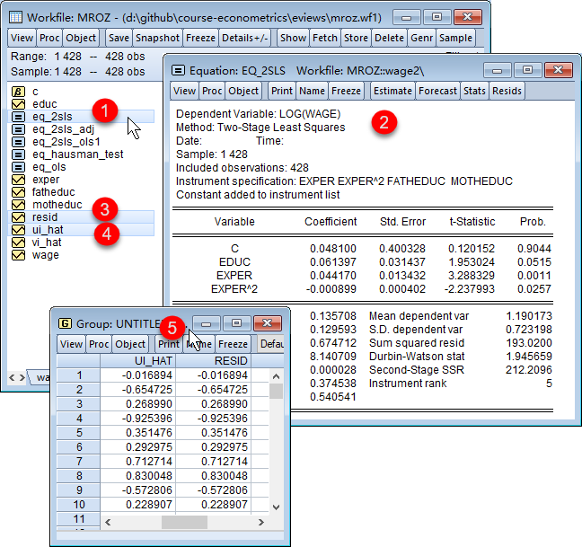

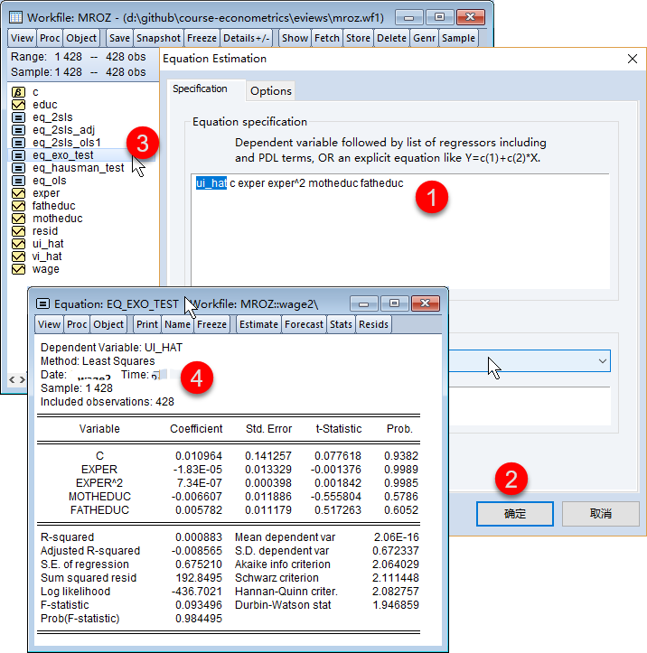

工具外生性检验的EViews最终结果为：

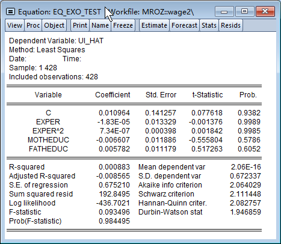